# The Central Limit Theorem

# Introduction

The Central Limit Theorem (CLT)states that the distribution of averages of iid variables (properly normalized) becomes that of a standard normal as the *sample size increases*. This means that it is possible to get an approximation of mean and standard deviation for the whole distribution with only one observed average and without knowing the population distribution.

The result of increasing sample size is that $\frac{\bar X_n - \mu}{\sigma / \sqrt{n}}= \frac{\sqrt n (\bar X_n - \mu)}{\sigma} = \frac{\mbox{Estimate} - \mbox{Mean of estimate}}{\mbox{Std. Err. of estimate}}$  
converges on a distribution similar to that of the standard normal range for large $n$

The useful way to think about the CLT is that $\bar X_n$ is approximately $N(\mu, \sigma^2 / n)$

```r
library(knitr)
library(dplyr)
library(reshape2)
library(ggplot2)
```

# Test the Central Limit Theorem by simulation:

## Some Initial Assumptions

The theoretical mean ($\mu$) and variance $Var$ of exponential distribution with parameter $\lambda$ are respectively $1/\lambda$ and $1/\lambda^2$,

If the CLT is true, then:

The mean of our simulation $\bar X_n$ should approach $\mu$, i.e., $\frac{1}{0.2}$ or: 5

The variance of our simulation, $Var_n$ should approach $1/\lambda^2$, i.e, $\frac{1}{0.2^2}$ or 25

# Set Constants

- The rate parameter, $\lambda$ , as prescribed by the assignment, is 0.2
- The number of random exponentials to means test, $n$ is 40.
- The seed is 127
- The number of simulations of 40 random exponents is 1000
- Theoretical constants:  
  - Theoretical means - Standard deviation  
  - Variance of sample mean
- set the options to display four digits after the decimal.

```r
l = 0.2 #lambda, as prescribed in assignment
ex = 40 #number of exponentials examined
sims = 1000 #number of simulations
set.seed(127)#seed set for reproducibility

tmean<-1/l #theoretical mean
tsd<-1/l/sqrt(ex) #theoritical standard deviation
tvar<-(1/l/sqrt(ex))^2 #theoretical variance

options(digits = 4)
```

Create a matrix 40 columns by 1000 rows using the same random seed

Each sample consists of 40 random exponents, the seed is set to 127.  
This sample is drawn 1000 times.

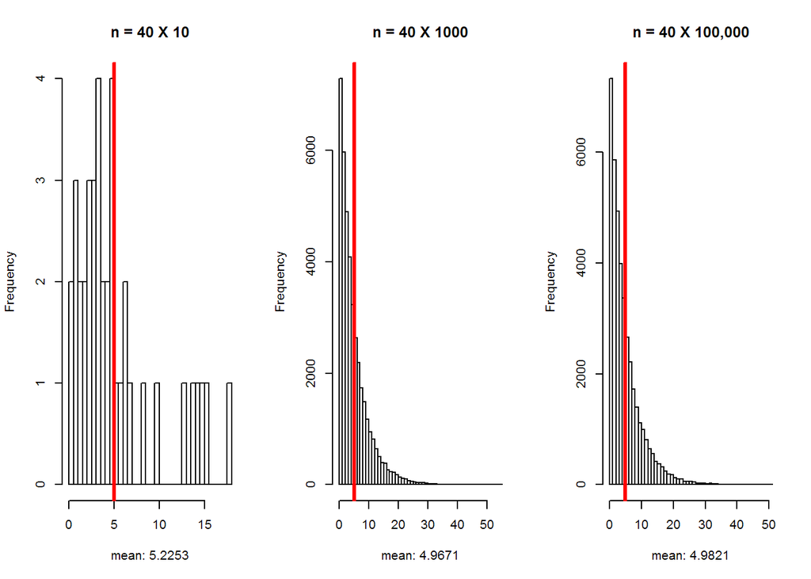

```r
small<-matrix(rexp(ex*sims/1000, .2), nrow=sims/1000, ncol=ex)
medium <- matrix(rexp(ex * sims, .2), nrow = sims, ncol=ex)
large<-matrix(rexp(ex*sims*100, .2), nrow=sims, ncol=ex)

par(mfrow=c(1,3))
hist(small, breaks = 40, main="n = 40 X 10", xlab=paste("mean:", round(mean(small), digits = 4), sep=" "))
abline(v=mean(medium), col="red", lwd=3)

hist(medium, breaks = 40, main="n = 40 X 1000", xlab=paste("mean:", round(mean(medium), digits = 4), sep=" "))
abline(v=mean(medium), col="red", lwd=3)

hist(large, breaks = 40, main="n = 40 X 100,000", xlab=paste("mean:", round(mean(large), digits = 4), sep=" "))
abline(v=mean(large), col="red", lwd=3)
```

Now let’s take a look at the mean of the each of the 40 sample draws:

```r
#create a data frame of sample means for our small set
small<-data.frame(value=rowMeans(small))

#create a data frame of sample means for our medium set
medium<-data.frame(value=rowMeans(medium))

#create a data frame of sample means for our large set
large<-data.frame(value=rowMeans(large))

#melt the data for ease of use in ggplot2 facets
all<-melt(data=c(sample1=small, sample2=medium, sample3=large), variable.name = "variable")

##some calculations that will come in handy as we generate our plots:

#calculate the sample mean
smean<-mean(all$value)

#calculate the sample standard deviation
ssd<-sd(all$value)

#calculate the sample variance
svar<-var(all$value)
```

# Comparison of Three Sets of Sample Means

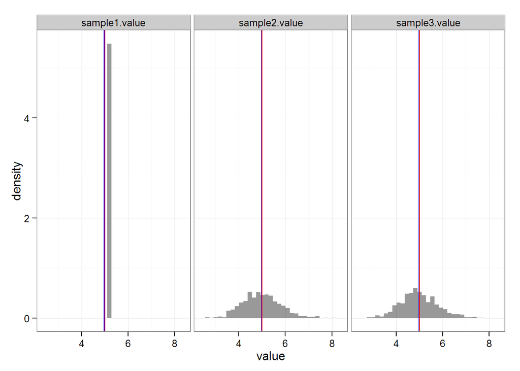

```r
ch1<-ggplot(all, aes(value), col=L1, width="600px")+
        geom_histogram(aes(y =..density..), alpha=.5)+
        geom_vline(xintercept=mean(all$value), col="blue")+
        geom_vline(xintercept=tmean, col="red")+
        theme_bw()+
        facet_grid(.~L1, scales="free_y")
ch1
```

The theoretical mean, $\mu$ and the sample mean $\bar X$ are very close in all three plots.

```r
#calculate the sample mean
smean<-mean(all$value)

#calculate the sample standard deviation
ssd<-sd(all$value)

#calculate the sample variance
svar<-var(all$value)
```

## Compare Variance of the Sample Mean:

Plugging in the values, $\lambda$ = .2, $n$=40:

The **Theoretical** $Var$, $\sigma^2$, of sample means is **0.625** (in red, below)

The **Calculated** $Var$, $Var_n(\bar X)$, of the sample mean is **0.637** (in blue, below)

```
## stat_bin: binwidth defaulted to range/30. Use 'binwidth = x' to adjust this.
## stat_bin: binwidth defaulted to range/30. Use 'binwidth = x' to adjust this.
## stat_bin: binwidth defaulted to range/30. Use 'binwidth = x' to adjust this.
```

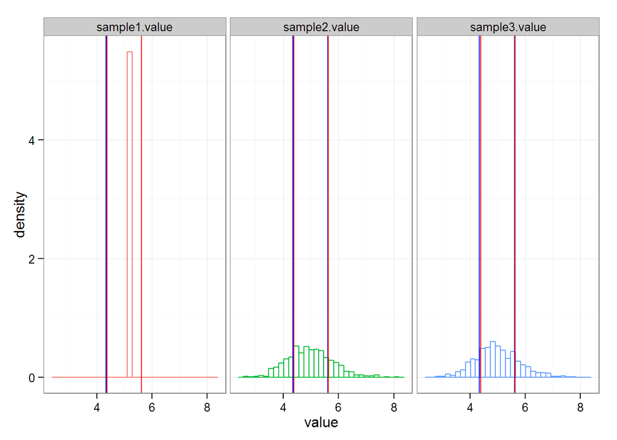

```r
ch2<-ggplot(all, aes(value))+
        geom_histogram(aes(y =..density.., col=L1), fill=NA, alpha=.3)+
        geom_vline(xintercept=c(smean-svar, smean+svar), col="blue")+
        geom_vline(xintercept=c(tmean-tvar, tmean+tvar), col="red")+
        theme_bw()+
        theme(legend.position="none")+
        facet_grid(.~L1, scales="free_y")

ch2
```

## Compare Density Distribution:

As the number of means of sample means ($n$ times the number of simulations) increases, the density plot should more closely resemble the Normal density plot.

To compare densities, we can overlay a density plot for the distribution of the calculated sample means with a theoretical normal distribution density (the classic $bell$ curve) to test this.

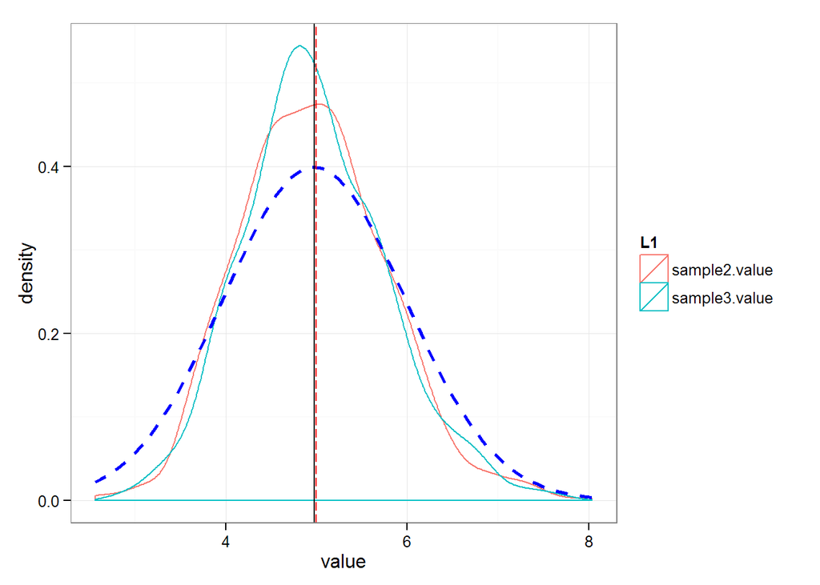

```r
ch3<-ggplot(all, aes(value, col=L1))+
        geom_density()+
        stat_function(fun=dnorm, args=list(mean(all$value, sd=sd(all$value))), col="blue",lwd=1, lty=2)+
        geom_vline(xintercept=mean(all$value), stat="vline")+
        geom_vline(xintercept=1/l, stat_vline=1/l, col="red", linetype = "longdash")+
        theme_bw()

ch3
```

*(for smaller numbers, the sample number is corrected by subtracting 1, but we’re working with larger sample sizes here, so we’ll stick with $n$)